# Body mass index-dependent shifts along large-scale gradients in human cortical organization explain dietary regulatory success

R. Janet, J. Smallwood, C. A. Hutcherson, H. Plassmann, B. Mckeown, A. Tusche

September 2023

This script contain the code for the main results of the paper. The data used in this analysis pipeline are stored in the file named Data.csv.

Installing required packages and loading libraries

```r
####################### Load libraries #########################################
library(plyr) # for data manipulation
library(tidyverse) #for removing rows with missing values.
library(lme4) #for LMMs
```

```r
library(emmeans) #for saving predicted values for graphs and posthoc contrasts
library(data.table) # for data manipulation
library(ggthemes) #for formatting graphs
library(patchwork) # for putting plots together in one figure
library(report) # can use to get written summary of results if required
library(sjPlot) #for creating supplementary tables
library(effectsize)# to calculate standardized parameters for models if required
library(dplyr) # data manipulation
library(interactions) # plotting interactions
library(performance) # checking performance of models
library(lmerTest) #for p-values for LMMs
library(ggplot2)
library(effectsize)
library(effects)
library(ggeffects)
library(interactions)
library(sjPlot)
library(jtools)
```

Loading the data and store them into mydata.

```r
mydata <- read.csv("C:\\Users\\Neuroeconomics Lab\\Documents\\Articles\\Gradients_Food\\May_2023\\August 2023\\RJ_15_August\\PNAS review\\Data.csv" , head = TRUE, sep=",")

# create categorical data
mydata$sex <- as.factor(mydata$sex)
mydata$Study <- as.factor(mydata$Study)
```

Plotting the similarity between the brain state in NC and HC and the gradient 1

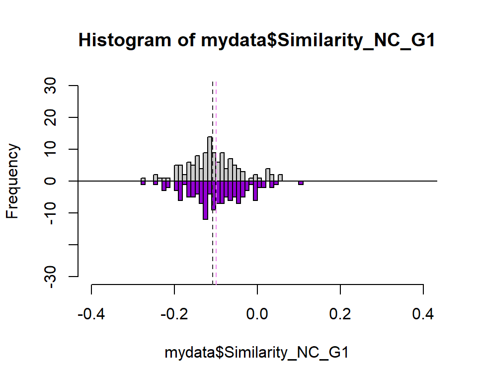

```r
h1 = hist(mydata$Similarity_NC_G1, breaks=30, plot=FALSE)
h2 = hist(mydata$Similarity_HC_G1, breaks=30, plot=FALSE)
h2$counts = - h2$counts
hmax = max(h1$counts)
hmin = min(h2$counts)
X = c(h1$breaks, h2$breaks)
xmax = 0.4
xmin = -0.4
plot(h1, ylim=c(-30, 30), col="gray80", xlim=c(xmin, xmax))
lines(h2, col="darkviolet")
abline(h=0, col="black")
abline(v=c(-0.1074, -0.0991), col=c("gray20", "violet"), lty=c(2, 2))
```

Plotting the similarity between the brain state in NC and HC and the gradient 2

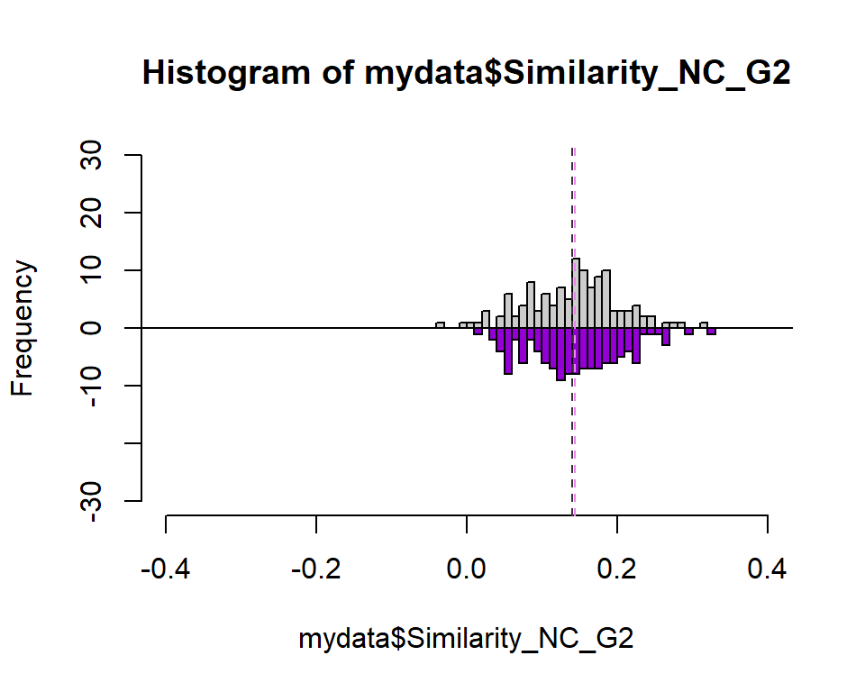

```r
h1 = hist(mydata$Similarity_NC_G2, breaks=30, plot=FALSE)
h2 = hist(mydata$Similarity_HC_G2, breaks=30, plot=FALSE)
h2$counts = - h2$counts
hmax = max(h1$counts)
hmin = min(h2$counts)
X = c(h1$breaks, h2$breaks)
xmax = 0.4
xmin = -0.4
plot(h1, ylim=c(-30, 30), col="gray80", xlim=c(xmin, xmax))
lines(h2, col="darkviolet")
abline(h=0, col="black")
abline(v=c(0.14, 0.1443), col=c("gray20", "violet"), lty=c(2, 2))
```

Plotting the similarity between the brain state in NC and HC and the gradient 3

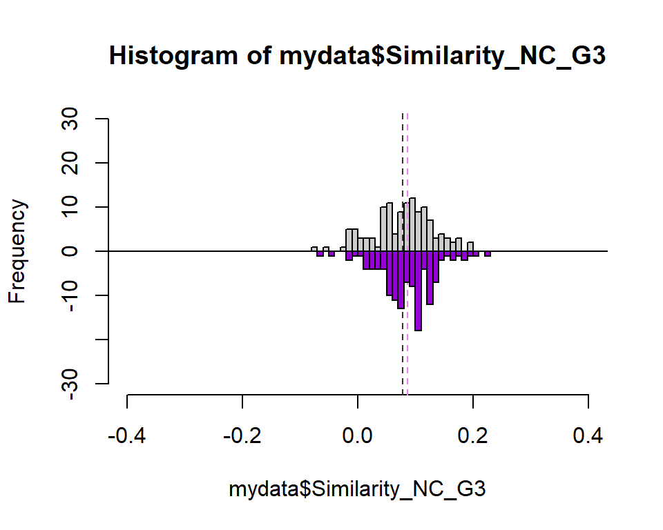

```r
h1 = hist(mydata$Similarity_NC_G3, breaks=30, plot=FALSE)
h2 = hist(mydata$Similarity_HC_G3, breaks=30, plot=FALSE)
h2$counts = - h2$counts
hmax = max(h1$counts)
hmin = min(h2$counts)
X = c(h1$breaks, h2$breaks)
xmax = 0.4
xmin = -0.4
plot(h1, ylim=c(-30, 30), col="gray80", xlim=c(xmin, xmax))
abline(v=c(0.0783, 0.0868), col=c("gray20", "violet"), lty=c(2, 2))
lines(h2, col="darkviolet")
abline(h=0, col="black")
```

Performed the GLMs

```r
mdl00 <- lmer(RS ~ (1|Study), data = mydata, REML = FALSE)
mdl01 <- lmer(RS ~ Age + sex + BMI + (1|Study), data = mydata, REML = FALSE)
mdl02 <- lmer(RS ~ HCvsNCG1+HCvsNCG2+HCvsNCG3 + Age + sex + BMI + (1|Study), data = mydata, REML = FALSE)
mdl03 <- lmer(RS ~ HCvsNCG1*HCvsNCG2*HCvsNCG3 + Age + sex + BMI + (1|Study), data = mydata, REML = FALSE)
mdl04 <- lmer(RS ~ ED_HCvsNC + Age + sex + BMI + (1|Study), data = mydata, REML = FALSE)
mdl05 <- lmer(RS ~ ED_HCvsNC*BMI + Age + sex + (1|Study), data = mydata, REML = FALSE)
```

Compare the fitting using the AIC

```r
library(performance)
compare_performance(mdl00, mdl01, mdl02, mdl03, mdl04, mdl05, metrics = "AIC", rank = TRUE)
```

```
## # Comparison of Model Performance Indices
##
## Name  |           Model | AIC weights | Performance-Score
## ---------------------------------------------------------
## mdl05 | lmerModLmerTest |       0.673 |           100.00%
## mdl04 | lmerModLmerTest |       0.106 |            12.24%
## mdl00 | lmerModLmerTest |       0.093 |            10.20%
## mdl01 | lmerModLmerTest |       0.072 |             6.91%
## mdl02 | lmerModLmerTest |       0.029 |             0.30%
## mdl03 | lmerModLmerTest |       0.027 |             0.00%
```

```r
anova(mdl00, mdl01, mdl02, mdl03, mdl04, mdl05)
```

```
## Data: mydata
## Models:
## mdl00: RS ~ (1 | Study)
## mdl01: RS ~ Age + sex + BMI + (1 | Study)
## mdl04: RS ~ ED_HCvsNC + Age + sex + BMI + (1 | Study)
## mdl05: RS ~ ED_HCvsNC * BMI + Age + sex + (1 | Study)
## mdl02: RS ~ HCvsNCG1 + HCvsNCG2 + HCvsNCG3 + Age + sex + BMI + (1 | Study)
## mdl03: RS ~ HCvsNCG1 * HCvsNCG2 * HCvsNCG3 + Age + sex + BMI + (1 | Study)
##       npar    AIC    BIC   logLik deviance  Chisq Df Pr(>Chisq)
## mdl00    3 211.36 219.79 -102.679   205.36
## mdl01    6 211.88 228.75  -99.938   199.88 5.4805  3    0.13981
## mdl04    7 211.09 230.78  -98.546   197.09 2.7857  1    0.09511 .
## mdl05    8 207.40 229.89  -95.698   191.40 5.6947  1    0.01702 *
## mdl02    9 213.69 239.00  -97.844   195.69 0.0000  1    1.00000
## mdl03   13 213.83 250.38  -93.913   187.83 7.8620  4    0.09677 .
## ---
## Signif. codes:  0 '***' 0.001 '**' 0.01 '*' 0.05 '.' 0.1 ' ' 1
```

Plot the summary of the best model (mdl05)

```r
summary(mdl05)
```

```
## Linear mixed model fit by maximum likelihood . t-tests use Satterthwaite's
##   method [lmerModLmerTest]
## Formula: RS ~ ED_HCvsNC * BMI + Age + sex + (1 | Study)
##    Data: mydata
##
##      AIC      BIC   logLik deviance df.resid
##    207.4    229.9    -95.7    191.4      115
##
## Scaled residuals:
##     Min      1Q  Median      3Q     Max
## -2.0545 -0.6554 -0.0589  0.6218  2.7926
##
## Random effects:
##  Groups   Name        Variance Std.Dev.
##  Study    (Intercept) 0.08907  0.2984
##  Residual             0.25996  0.5099
## Number of obs: 123, groups:  Study, 3
##
## Fixed effects:
##                 Estimate Std. Error         df t value Pr(>|t|)
## (Intercept)     1.723041   0.751767 114.864812   2.292  0.02373 *
## ED_HCvsNC     -24.834421   9.398428 119.905203  -2.642  0.00933 **
## BMI            -0.055660   0.029920 120.155514  -1.860  0.06529 .
## Age             0.018414   0.009163 122.286569   2.010  0.04667 *
## sex1           -0.046900   0.113103 122.951927  -0.415  0.67911
## ED_HCvsNC:BMI   0.996373   0.412196 120.350033   2.417  0.01714 *
## ---
## Signif. codes:  0 '***' 0.001 '**' 0.01 '*' 0.05 '.' 0.1 ' ' 1
##
## Correlation of Fixed Effects:
##             (Intr) ED_HCvNC BMI    Age    sex1
## ED_HCvsNC   -0.761
## BMI         -0.881  0.847
## Age         -0.304 -0.034   -0.077
## sex1        -0.218 -0.045    0.077  0.126
## ED_HCNC:BMI  0.741 -0.990   -0.855  0.057  0.045
```

Plot the main effect the Euclidean distance (ED_HCvsNC) on Regulatory success (RS)

```
## Confidence intervals for merMod models is an experimental feature. The
## intervals reflect only the variance of the fixed effects, not the random
## effects.
```

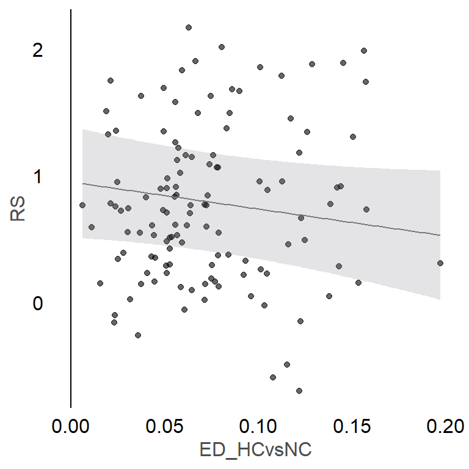

```r
effect_plot(mdl05, pred = ED_HCvsNC, interval = TRUE, plot.points = TRUE, line.thickness = 0.5, line.colors ="#797980")+set_theme(
  base = theme_blank(),
  axis.title.size = 1,
  axis.textsize = 1,
  legend.size = 1,
  legend.title.size = 1,
  geom.label.size = 1,
  panel.gridcol = TRUE,
  panel.major.linetype = 0,
  panel.minor.linetype = 0,
  geom.alpha = 1,
  axis.textcolor.x = "black",
  axis.textcolor.y = "black",
  title.color = "black",
  legend.title.color = "black",
  legend.color = "black"
)  + geom_vline(xintercept = 0,linetype="solid")
```

Plotting the BMI - Euclidean Distance interaction, splitting the BMI in three groups (terciles option)

```r
PPP <- interact_plot(mdl05, pred = "ED_HCvsNC", modx = "BMI", interval = TRUE, int.width = 0.95, modx.values = "terciles", colors = c("navy", "royalblue", "deepskyblue"))
```

```
## Medians of each tercile of BMI are 20.1, 22.3, 25.8
```

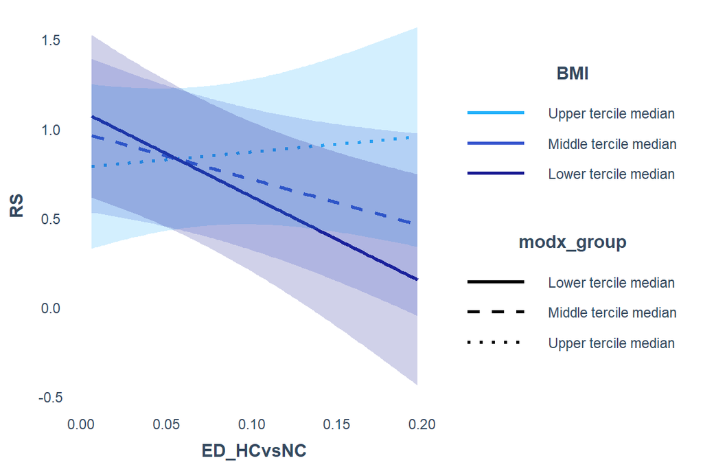

```r
PPP <- PPP + theme(panel.grid.major = element_blank())+
scale_linetype_manual(values=c("solid","dashed","dotted"))
PPP
```

Supplementary analysis:

```r
# Find tertiles
vTert = quantile(mydata$BMI, c(0:3/3))

# classify values
mydata$BMItercile = with(mydata,
               cut(BMI,
                   vTert,
                   include.lowest = T,
                   labels = c("Low", "Medium", "High")))

mydata$BMItercile = as.numeric(mydata$BMItercile)

mdl05_tercile <- lmer(RS ~ ED_HCvsNC*BMItercile + Age + sex + (1|Study), data = mydata, REML = FALSE)
summary(mdl05_tercile)
```

```
## Linear mixed model fit by maximum likelihood . t-tests use Satterthwaite's
##   method [lmerModLmerTest]
## Formula: RS ~ ED_HCvsNC * BMItercile + Age + sex + (1 | Study)
##    Data: mydata
##
##      AIC      BIC   logLik deviance df.resid
##    208.2    230.7    -96.1    192.2      115
##
## Scaled residuals:
##      Min       1Q   Median       3Q      Max
## -2.03797 -0.64949 -0.08139  0.60658  2.78884
##
## Random effects:
##  Groups   Name        Variance Std.Dev.
##  Study    (Intercept) 0.1001   0.3164
##  Residual             0.2610   0.5108
## Number of obs: 123, groups:  Study, 3
##
## Fixed effects:
##                        Estimate Std. Error         df t value Pr(>|t|)
## (Intercept)            0.846726   0.434756  48.098765   1.948  0.05731 .
## ED_HCvsNC             -8.734298   3.231451 120.108380  -2.703  0.00787 **
## BMItercile            -0.183976   0.123694 120.091034  -1.487  0.13955
## Age                    0.018236   0.009181 122.665681   1.986  0.04922 *
## sex1                  -0.037673   0.116008 122.965803  -0.325  0.74593
## ED_HCvsNC:BMItercile   3.083413   1.446532 119.886512   2.132  0.03508 *
## ---
## Signif. codes:  0 '***' 0.001 '**' 0.01 '*' 0.05 '.' 0.1 ' ' 1
##
## Correlation of Fixed Effects:
##             (Intr) ED_HCvNC BMItrc Age    sex1
## ED_HCvsNC   -0.546
## BMItercile  -0.555  0.776
## Age         -0.622  0.023   -0.048
## sex1        -0.339 -0.017    0.143  0.131
## ED_HCNC:BMI  0.464 -0.907   -0.876  0.050  0.004
```

```r
sim_slopes(mdl05_tercile, pred = "ED_HCvsNC", modx = "BMItercile", modx.values = "terciles")
```

```
## Medians of each tercile of BMItercile are 1, 2, 3
```

```
## JOHNSON-NEYMAN INTERVAL
##
## When BMItercile is OUTSIDE the interval [1.95, 13.93], the slope of
## ED_HCvsNC is p < .05.
##
## Note: The range of observed values of BMItercile is [1.00, 3.00]
##
## SIMPLE SLOPES ANALYSIS
##
## Slope of ED_HCvsNC when BMItercile = 1.00 (Lower tercile median):
##
##    Est.   S.E.   t val.      p
## ------- ------ -------- ------
##   -5.65   2.01    -2.80   0.01
##
## Slope of ED_HCvsNC when BMItercile = 2.00 (Middle tercile median):
##
##    Est.   S.E.   t val.      p
## ------- ------ -------- ------
##   -2.57   1.36    -1.88   0.06
##
## Slope of ED_HCvsNC when BMItercile = 3.00 (Upper tercile median):
##
##   Est.   S.E.   t val.      p
## ------ ------ -------- ------
##   0.52   1.96     0.26   0.79
```

Perform similar analysis using the weigth participant attributed to taste and health in the health focus condition. TASTE

```r
mdl5_noZ_HCTR <- lmer(HCTR ~ ED_HCvsNC*BMI + Age + sex + (1|Study), data = mydata, REML = FALSE)
summary(mdl5_noZ_HCTR)
```

```
## Linear mixed model fit by maximum likelihood . t-tests use Satterthwaite's
##   method [lmerModLmerTest]
## Formula: HCTR ~ ED_HCvsNC * BMI + Age + sex + (1 | Study)
##    Data: mydata
##
##      AIC      BIC   logLik deviance df.resid
##     65.0     87.5    -24.5     49.0      115
##
## Scaled residuals:
##      Min       1Q   Median       3Q      Max
## -2.56082 -0.51290  0.07807  0.64595  2.02558
##
## Random effects:
##  Groups   Name        Variance Std.Dev.
##  Study    (Intercept) 0.01836  0.1355
##  Residual             0.08246  0.2872
## Number of obs: 123, groups:  Study, 3
##
## Fixed effects:
##                 Estimate Std. Error         df t value Pr(>|t|)
## (Intercept)    -0.897861   0.418792 119.520204  -2.144   0.0341 *
## ED_HCvsNC      12.007995   5.292170 119.890465   2.269   0.0251 *
## BMI             0.029063   0.016844 120.249746   1.725   0.0870 .
## Age            -0.009406   0.005117 118.586688  -1.838   0.0685 .
## sex1            0.075261   0.063377 122.772846   1.188   0.2373
## ED_HCvsNC:BMI  -0.477265   0.232005 120.528260  -2.057   0.0418 *
## ---
## Signif. codes:  0 '***' 0.001 '**' 0.01 '*' 0.05 '.' 0.1 ' ' 1
##
## Correlation of Fixed Effects:
##             (Intr) ED_HCvNC BMI    Age    sex1
## ED_HCvsNC   -0.769
## BMI         -0.891  0.847
## Age         -0.303 -0.033   -0.077
## sex1        -0.217 -0.046    0.075  0.121
## ED_HCNC:BMI  0.749 -0.990   -0.855  0.057  0.048
```

```
## Confidence intervals for merMod models is an experimental feature. The
## intervals reflect only the variance of the fixed effects, not the random
## effects.
```

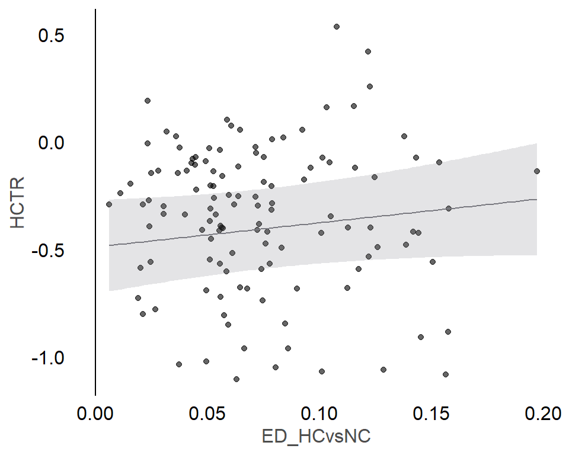

```r
effect_plot(mdl5_noZ_HCTR, pred = ED_HCvsNC, interval = TRUE, plot.points = TRUE, line.thickness = 0.5, line.colors ="#797980")+set_theme(
  base = theme_blank(),
  axis.title.size = 1,
  axis.textsize = 1,
  legend.size = 1,
  legend.title.size = 1,
  geom.label.size = 1,
  panel.gridcol = TRUE,
  panel.major.linetype = 0,
  panel.minor.linetype = 0,
  geom.alpha = 1,
  axis.textcolor.x = "black",
  axis.textcolor.y = "black",
  title.color = "black",
  legend.title.color = "black",
  legend.color = "black"
)  + geom_vline(xintercept = 0,linetype="solid")
```

```r
sim_slopes(mdl5_noZ_HCTR, pred = "ED_HCvsNC", modx = "BMI", modx.values = "terciles")
```

```
## Medians of each tercile of BMI are 20.1, 22.3, 25.8
```

```
## JOHNSON-NEYMAN INTERVAL
##
## When BMI is OUTSIDE the interval [21.95, 94.19], the slope of ED_HCvsNC is
## p < .05.
##
## Note: The range of observed values of BMI is [15.94, 32.99]
##
## SIMPLE SLOPES ANALYSIS
##
## Slope of ED_HCvsNC when BMI = 20.10 (Lower tercile median):
##
##   Est.   S.E.   t val.      p
## ------ ------ -------- ------
##   2.41   0.95     2.54   0.01
##
## Slope of ED_HCvsNC when BMI = 22.30 (Middle tercile median):
##
##   Est.   S.E.   t val.      p
## ------ ------ -------- ------
##   1.36   0.76     1.79   0.08
##
## Slope of ED_HCvsNC when BMI = 25.80 (Upper tercile median):
##
##    Est.   S.E.   t val.      p
## ------- ------ -------- ------
##   -0.31   1.07    -0.29   0.77
```

```r
PPP <- interact_plot(mdl5_noZ_HCTR, pred = "ED_HCvsNC", modx = "BMI", interval = TRUE, int.width = 0.95, modx.values = "terciles", colors = c("navy", "royalblue", "deepskyblue"))
```

```
## Medians of each tercile of BMI are 20.1, 22.3, 25.8
```

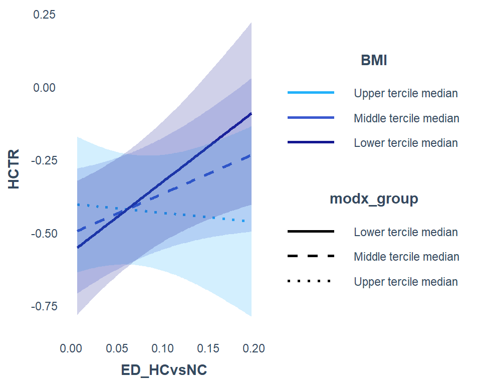

```r
PPP <- PPP + theme(panel.grid.major = element_blank())+
scale_linetype_manual(values=c("solid","dashed","dotted"))
PPP
```

HEALTH

```
## Confidence intervals for merMod models is an experimental feature. The
## intervals reflect only the variance of the fixed effects, not the random
## effects.
```

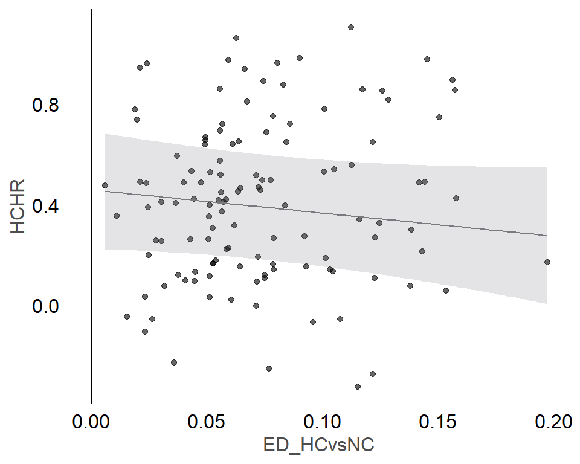

```r
mdl5_noZ_HCHR <- lmer(HCHR ~ ED_HCvsNC*BMI + Age + sex + (1|Study), data = mydata, REML = FALSE)

effect_plot(mdl5_noZ_HCHR, pred = ED_HCvsNC, interval = TRUE, plot.points = TRUE, line.thickness = 0.5, line.colors ="#797980")+set_theme(
  base = theme_blank(),
  axis.title.size = 1,
  axis.textsize = 1,
  legend.size = 1,
  legend.title.size = 1,
  geom.label.size = 1,
  panel.gridcol = TRUE,
  panel.major.linetype = 0,
  panel.minor.linetype = 0,
  geom.alpha = 1,
  axis.textcolor.x = "black",
  axis.textcolor.y = "black",
  title.color = "black",
  legend.title.color = "black",
  legend.color = "black"
)  + geom_vline(xintercept = 0,linetype="solid")
```

```r
sim_slopes(mdl5_noZ_HCHR, pred = "ED_HCvsNC", modx = "BMI", modx.values = "terciles")
```

```
## Medians of each tercile of BMI are 20.1, 22.3, 25.8
```

```
## JOHNSON-NEYMAN INTERVAL
##
## When BMI is OUTSIDE the interval [21.76, 35.52], the slope of ED_HCvsNC is
## p < .05.
##
## Note: The range of observed values of BMI is [15.94, 32.99]
##
## SIMPLE SLOPES ANALYSIS
##
## Slope of ED_HCvsNC when BMI = 20.10 (Lower tercile median):
##
##    Est.   S.E.   t val.      p
## ------- ------ -------- ------
##   -2.34   0.90    -2.61   0.01
##
## Slope of ED_HCvsNC when BMI = 22.30 (Middle tercile median):
##
##    Est.   S.E.   t val.      p
## ------- ------ -------- ------
##   -1.18   0.72    -1.64   0.10
##
## Slope of ED_HCvsNC when BMI = 25.80 (Upper tercile median):
##
##   Est.   S.E.   t val.      p
## ------ ------ -------- ------
##   0.66   1.01     0.66   0.51
```

```r
PPP <- interact_plot(mdl5_noZ_HCHR, pred = "ED_HCvsNC", modx = "BMI", interval = TRUE, int.width = 0.95, modx.values = "terciles", colors = c("navy", "royalblue", "deepskyblue"))
```

```
## Medians of each tercile of BMI are 20.1, 22.3, 25.8
```

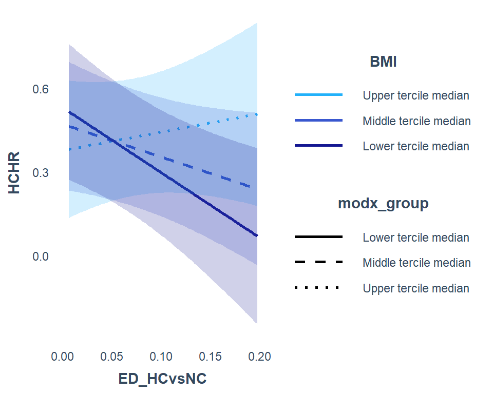

```r
PPP <- PPP + theme(panel.grid.major = element_blank())+
scale_linetype_manual(values=c("solid","dashed","dotted"))
PPP
```

Controlling for the natural ability to make healthy choices

```r
mdl5_noZ_NDS <- lmer(RS ~ ED_HCvsNC*BMI + NDS + Age + sex + (1|Study), data = mydata, REML = FALSE)
```

```
## boundary (singular) fit: see help('isSingular')
```

```r
summary(mdl5_noZ_NDS)
```

```
## Linear mixed model fit by maximum likelihood . t-tests use Satterthwaite's
##   method [lmerModLmerTest]
## Formula: RS ~ ED_HCvsNC * BMI + NDS + Age + sex + (1 | Study)
##    Data: mydata
##
##      AIC      BIC   logLik deviance df.resid
##    174.8    200.1    -78.4    156.8      114
##
## Scaled residuals:
##      Min       1Q   Median       3Q      Max
## -2.38441 -0.69455  0.01832  0.71153  2.08675
##
## Random effects:
##  Groups   Name        Variance Std.Dev.
##  Study    (Intercept) 0.0000   0.0000
##  Residual             0.2095   0.4577
## Number of obs: 123, groups:  Study, 3
##
## Fixed effects:
##                 Estimate Std. Error         df t value Pr(>|t|)
## (Intercept)     1.190901   0.643439 123.000000   1.851  0.06659 .
## ED_HCvsNC     -18.117667   8.517273 123.000000  -2.127  0.03540 *
## BMI            -0.058625   0.026725 123.000000  -2.194  0.03014 *
## NDS            -0.881605   0.113757 123.000000  -7.750 2.96e-12 ***
## Age             0.018968   0.006695 123.000000   2.833  0.00539 **
## sex1           -0.139546   0.093495 123.000000  -1.493  0.13812
## ED_HCvsNC:BMI   0.803430   0.371251 123.000000   2.164  0.03239 *
## ---
## Signif. codes:  0 '***' 0.001 '**' 0.01 '*' 0.05 '.' 0.1 ' ' 1
##
## Correlation of Fixed Effects:
##             (Intr) ED_HCvNC BMI    NDS    Age    sex1
## ED_HCvsNC   -0.814
## BMI         -0.936  0.845
## NDS          0.152 -0.161   -0.075
## Age         -0.214 -0.029   -0.076  0.060
## sex1        -0.181 -0.052    0.053 -0.127  0.012
## ED_HCNC:BMI  0.800 -0.992   -0.850  0.172  0.039  0.070
## optimizer (nloptwrap) convergence code: 0 (OK)
## boundary (singular) fit: see help('isSingular')
```

```r
PPP <- interact_plot(mdl5_noZ_NDS, pred = "ED_HCvsNC", modx = "BMI", interval = TRUE, int.width = 0.95, modx.values = "terciles", colors = c("navy", "royalblue", "deepskyblue"))
```

```
## Medians of each tercile of BMI are 20.1, 22.3, 25.8
```

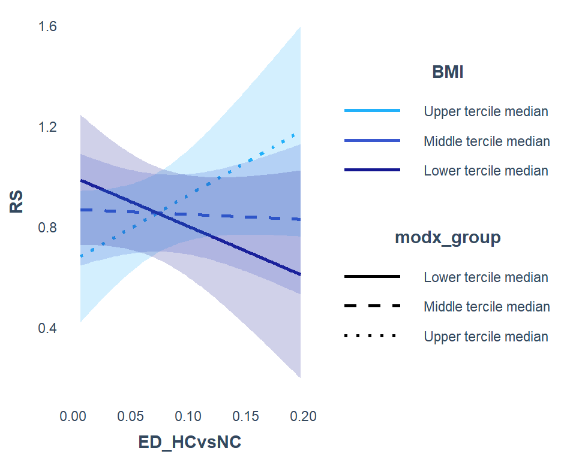

```r
PPP <- PPP + theme(panel.grid.major = element_blank())+
scale_linetype_manual(values=c("solid","dashed","dotted"))
PPP
```

Decomposing the Euclidean distance into the three main shift along each gradient individually and the triple interaction.

```r
mdlDecomp <- lmer(RS ~ HCvsNCG1 + HCvsNCG2 + HCvsNCG3 + BMI + (HCvsNCG1 : HCvsNCG2 : HCvsNCG3) * BMI + Age + sex + (1|Study), data = mydata, REML = FALSE)
summary(mdlDecomp)
```

```
## Linear mixed model fit by maximum likelihood . t-tests use Satterthwaite's
##   method [lmerModLmerTest]
## Formula:
## RS ~ HCvsNCG1 + HCvsNCG2 + HCvsNCG3 + BMI + (HCvsNCG1:HCvsNCG2:HCvsNCG3) *
##     BMI + Age + sex + (1 | Study)
##    Data: mydata
##
##      AIC      BIC   logLik deviance df.resid
##    210.7    241.7    -94.4    188.7      112
##
## Scaled residuals:
##      Min       1Q   Median       3Q      Max
## -2.19162 -0.74222 -0.04727  0.64223  2.73227
##
## Random effects:
##  Groups   Name        Variance Std.Dev.
##  Study    (Intercept) 0.06884  0.2624
##  Residual             0.25578  0.5058
## Number of obs: 123, groups:  Study, 3
##
## Fixed effects:
##                                  Estimate Std. Error         df t value
## (Intercept)                     1.787e-01  4.770e-01  8.144e+01   0.375
## HCvsNCG1                       -1.202e+00  8.943e-01  1.200e+02  -1.343
## HCvsNCG2                       -1.045e+00  1.001e+00  1.205e+02  -1.044
## HCvsNCG3                        8.048e-01  1.121e+00  1.205e+02   0.718
## BMI                             7.491e-03  1.567e-02  1.198e+02   0.478
## Age                             1.739e-02  9.043e-03  1.206e+02   1.923
## sex1                           -5.964e-02  1.128e-01  1.230e+02  -0.529
## HCvsNCG1:HCvsNCG2:HCvsNCG3      7.707e+03  3.689e+03  1.204e+02   2.089
## HCvsNCG1:HCvsNCG2:HCvsNCG3:BMI -2.899e+02  1.538e+02  1.205e+02  -1.885
##                                Pr(>|t|)
## (Intercept)                      0.7089
## HCvsNCG1                         0.1817
## HCvsNCG2                         0.2985
## HCvsNCG3                         0.4742
## BMI                              0.6334
## Age                              0.0569 .
## sex1                             0.5980
## HCvsNCG1:HCvsNCG2:HCvsNCG3       0.0388 *
```

[output cut: 10 more lines]

```
## Age                   -0.503  0.033   0.082  0.122 -0.060
## sex1                  -0.374 -0.076  -0.046 -0.103  0.211  0.103
## HCvNCG1:HCNCG2:HCNCG3 -0.064  0.010  -0.105  0.008  0.152 -0.061 -0.032
## HCNCG1:HCNCG2:HCNCG3:  0.074  0.001   0.106 -0.017 -0.162  0.054  0.034
##                       HCvNCG1:HCNCG2:HCNCG3
## HCvsNCG1
## HCvsNCG2
## HCvsNCG3
## BMI
## Age
## sex1
## HCvNCG1:HCNCG2:HCNCG3
## HCNCG1:HCNCG2:HCNCG3: -0.993
## fit warnings:
## Some predictor variables are on very different scales: consider rescaling
```

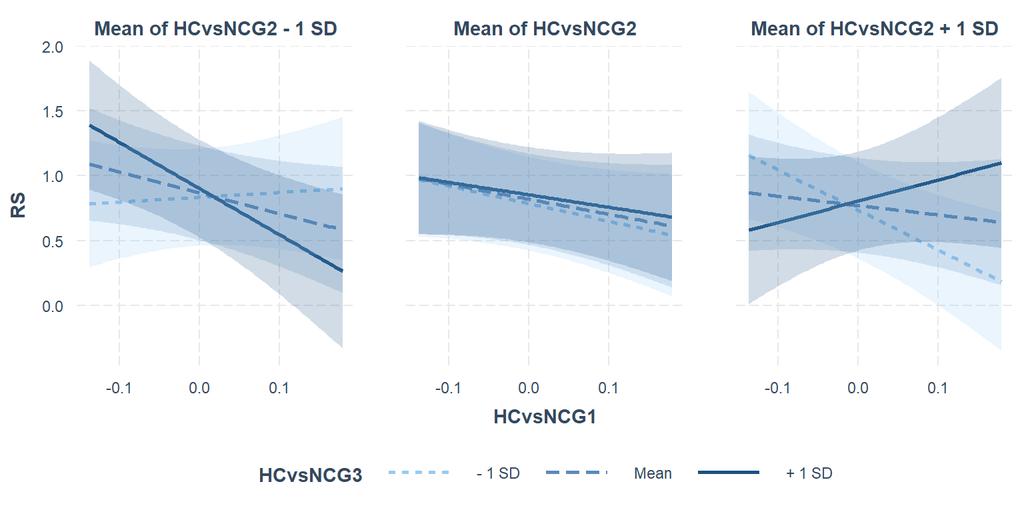

```r
interact_plot(mdlDecomp, pred = "HCvsNCG1", modx = "HCvsNCG3", mod2 = "HCvsNCG2", interval = TRUE, int.width = 0.95)
```